# Extra Credit Assignment- IST707

The analysis focuses on telecom customers who are likely to leave the platform.In this report we have used Decision Tree, Random forest and Support Vector Machine to predict the customers who are more likely to churn.

Dataset Source:https://www.kaggle.com/blastchar/telco-customer-churn

Submitted by: Jaishree Palaniswamy

#### Load the necessary packages

```r
library(ggplot2)
library(tidyverse)
library(dplyr)
library(tidyverse)
library(ggcorrplot)
library(caret)
library(caTools)
library(randomForest)
library(e1071)
library(pROC)
library(ROCR)
library(data.table)
```

#### Storing the data

```r
data <- read.csv("WA_Fn-UseC_-Telco-Customer-Churn.csv", header = TRUE)
```

```r
str(data)
```

```
## 'data.frame':    7043 obs. of  21 variables:
##  $ customerID      : chr  "7590-VHVEG" "5575-GNVDE" "3668-QPYBK" "7795-CFOCW" ...
##  $ gender          : chr  "Female" "Male" "Male" "Male" ...
##  $ SeniorCitizen   : int  0 0 0 0 0 0 0 0 0 0 ...
##  $ Partner         : chr  "Yes" "No" "No" "No" ...
##  $ Dependents      : chr  "No" "No" "No" "No" ...
##  $ tenure          : int  1 34 2 45 2 8 22 10 28 62 ...
##  $ PhoneService    : chr  "No" "Yes" "Yes" "No" ...
##  $ MultipleLines   : chr  "No phone service" "No" "No" "No phone service" ...
##  $ InternetService : chr  "DSL" "DSL" "DSL" "DSL" ...
##  $ OnlineSecurity  : chr  "No" "Yes" "Yes" "Yes" ...
##  $ OnlineBackup    : chr  "Yes" "No" "Yes" "No" ...
##  $ DeviceProtection: chr  "No" "Yes" "No" "Yes" ...
##  $ TechSupport     : chr  "No" "No" "No" "Yes" ...
##  $ StreamingTV     : chr  "No" "No" "No" "No" ...
##  $ StreamingMovies : chr  "No" "No" "No" "No" ...
##  $ Contract        : chr  "Month-to-month" "One year" "Month-to-month" "One year" ...
##  $ PaperlessBilling: chr  "Yes" "No" "Yes" "No" ...
##  $ PaymentMethod   : chr  "Electronic check" "Mailed check" "Mailed check" "Bank transfer (automatic)" ...
##  $ MonthlyCharges  : num  29.9 57 53.9 42.3 70.7 ...
##  $ TotalCharges    : num  29.9 1889.5 108.2 1840.8 151.7 ...
##  $ Churn           : chr  "No" "No" "Yes" "No" ...
```

```r
summary(data)
```

```
##   customerID           gender          SeniorCitizen      Partner
##  Length:7043        Length:7043        Min.   :0.0000   Length:7043
##  Class :character   Class :character   1st Qu.:0.0000   Class :character
##  Mode  :character   Mode  :character   Median :0.0000   Mode  :character
##                                        Mean   :0.1621
##                                        3rd Qu.:0.0000
##                                        Max.   :1.0000
##
##   Dependents            tenure      PhoneService       MultipleLines
##  Length:7043        Min.   : 0.00   Length:7043        Length:7043
##  Class :character   1st Qu.: 9.00   Class :character   Class :character
##  Mode  :character   Median :29.00   Mode  :character   Mode  :character
##                     Mean   :32.37
##                     3rd Qu.:55.00
##                     Max.   :72.00
##
##  InternetService    OnlineSecurity     OnlineBackup       DeviceProtection
##  Length:7043        Length:7043        Length:7043        Length:7043
##  Class :character   Class :character   Class :character   Class :character
##  Mode  :character   Mode  :character   Mode  :character   Mode  :character
##
##
##
##
##  TechSupport        StreamingTV        StreamingMovies      Contract
##  Length:7043        Length:7043        Length:7043        Length:7043
##  Class :character   Class :character   Class :character   Class :character
##  Mode  :character   Mode  :character   Mode  :character   Mode  :character
##
##
##
##
##  PaperlessBilling   PaymentMethod      MonthlyCharges    TotalCharges
##  Length:7043        Length:7043        Min.   : 18.25   Min.   :  18.8
##  Class :character   Class :character   1st Qu.: 35.50   1st Qu.: 401.4
##  Mode  :character   Mode  :character   Median : 70.35   Median :1397.5
##                                        Mean   : 64.76   Mean   :2283.3
##                                        3rd Qu.: 89.85   3rd Qu.:3794.7
##                                        Max.   :118.75   Max.   :8684.8
##                                                         NA's   :11
##     Churn
##  Length:7043
##  Class :character
##  Mode  :character
##
##
##
##
```

Check for NA values:

```r
sapply(data, function(x) sum(is.na(x)))
```

```
##       customerID           gender    SeniorCitizen          Partner
##                0                0                0                0
##       Dependents           tenure     PhoneService    MultipleLines
##                0                0                0                0
##  InternetService   OnlineSecurity     OnlineBackup DeviceProtection
##                0                0                0                0
##      TechSupport      StreamingTV  StreamingMovies         Contract
##                0                0                0                0
## PaperlessBilling    PaymentMethod   MonthlyCharges     TotalCharges
##                0                0                0               11
##            Churn
##                0
```

There are only 11 missing data in the TotalCharges field, so we can remove those rows from the dataset.

```r
data<-na.omit(data)
```

SeniorCitizen is in ‘int’ form, that can be changed to categorical.

```r
data$SeniorCitizen <- as.factor(ifelse(data$SeniorCitizen==1, 'YES', 'NO'))
```

Removing the duplicates:

```r
data <- data[!duplicated(data), ]
```

Visualization:

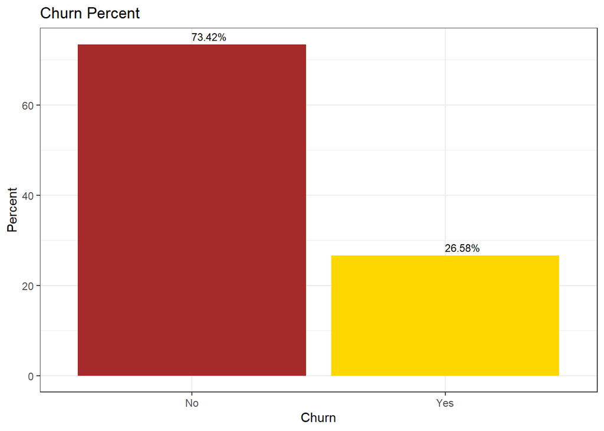

```r
data %>%
group_by(Churn) %>%
summarise(Count = n())%>%
mutate(percent = prop.table(Count)*100)%>%
ggplot(aes(reorder(Churn, -percent), percent), fill = Churn)+
geom_col(fill = c("brown", "gold"))+
geom_text(aes(label = sprintf("%.2f%%", percent)), hjust = 0.01,vjust = -0.5, size =3)+
theme_bw()+
xlab("Churn") +
ylab("Percent")+
ggtitle("Churn Percent")
```

Around 26% of customers left the platform within the last month

Tenure: The median tenure for customers who have left is around 10 months.

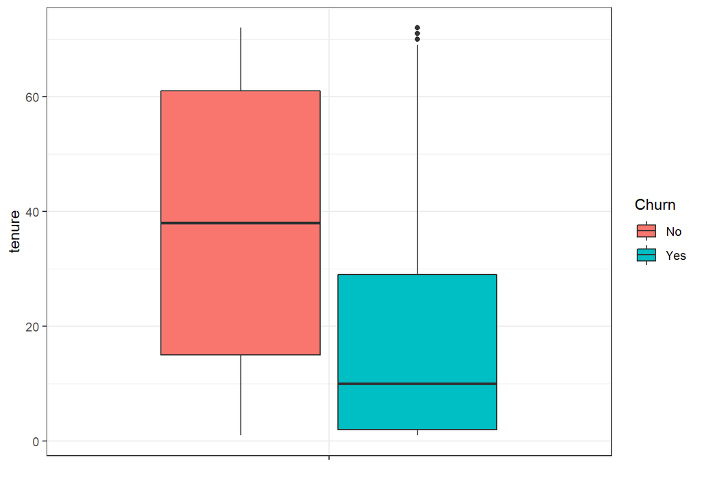

```r
ggplot(data, aes(y= tenure, x = "", fill = Churn)) +
geom_boxplot()+
theme_bw()+
xlab(" ")
```

MonthlyCharges: Customers who have churned, have high monthly charges. The median is above 75.

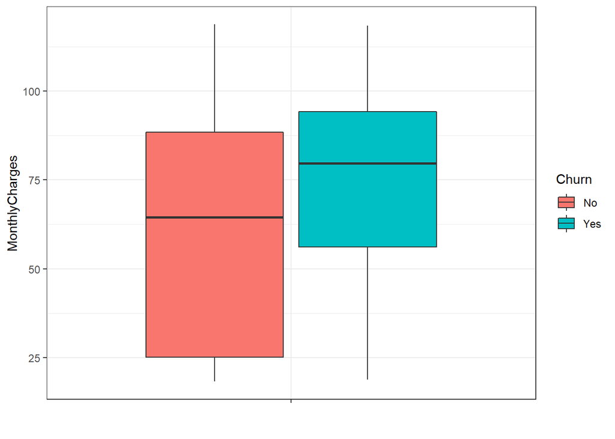

```r
ggplot(data, aes(y= MonthlyCharges, x = "", fill = Churn)) +
geom_boxplot()+
theme_bw()+
xlab(" ")
```

TotalCharges:* The median Total charges of customers who have churned is low.

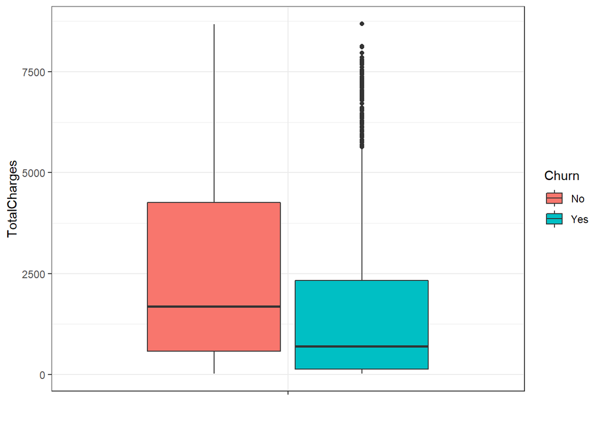

```r
ggplot(data, aes(y= TotalCharges, x = "", fill = Churn)) +
geom_boxplot()+
theme_bw()+
xlab(" ")
```

#### **Data Preparation**:

From the EDA above, we know that there are some categorical features that have ‘No’ and ‘No Internet Service’ or ‘No Phone Service’ as a category, we can make them as ‘No’ and clean these features.

```r
data <- data.frame(lapply(data, function(x) {
                  gsub("No internet service", "No", x)}))

data <- data.frame(lapply(data, function(x) {
                  gsub("No phone service", "No", x)}))

data$Churn <- as.factor(data$Churn)

data$customerID<-NULL
```

Standardising Continuous features

```r
num_columns <- c("tenure", "MonthlyCharges", "TotalCharges")
data[num_columns] <- sapply(data[num_columns], as.numeric)

data_int <- data[,c("tenure", "MonthlyCharges", "TotalCharges")]
data_int <- data.frame(scale(data_int))
```

I am trying to create a derived feature from tenure, where i have made different bins of tenure(which is in months) such as ‘0-1 year’, ‘2-3 years’, ‘3-4 years’ etc.

```r
data <- mutate(data, tenure_bin = tenure)

data$tenure_bin[data$tenure_bin >=0 & data$tenure_bin <= 12] <- '0-1 year'
data$tenure_bin[data$tenure_bin > 12 & data$tenure_bin <= 24] <- '1-2 years'
data$tenure_bin[data$tenure_bin > 24 & data$tenure_bin <= 36] <- '2-3 years'
data$tenure_bin[data$tenure_bin > 36 & data$tenure_bin <= 48] <- '3-4 years'
data$tenure_bin[data$tenure_bin > 48 & data$tenure_bin <= 60] <- '4-5 years'
data$tenure_bin[data$tenure_bin > 60 & data$tenure_bin <= 72] <- '5-6 years'

data$tenure_bin <- as.factor(data$tenure_bin)
```

Creating Dummy Variables:

```r
data_cat <- data[,-c(1,6,19,20)]

dummy<- data.frame(sapply(data_cat,function(x) data.frame(model.matrix(~x-1,data =data_cat))[,-1]))

head(dummy)
```

```
##   SeniorCitizen Partner Dependents MultipleLines InternetService.xFiber.optic
## 1             0       1          0             0                            0
## 2             0       0          0             0                            0
## 3             0       0          0             0                            0
## 4             0       0          0             0                            0
## 5             0       0          0             0                            1
## 6             0       0          0             1                            1
##   InternetService.xNo OnlineSecurity OnlineBackup DeviceProtection TechSupport
## 1                   0              0            1                0           0
## 2                   0              1            0                1           0
## 3                   0              1            1                0           0
## 4                   0              1            0                1           1
## 5                   0              0            0                0           0
## 6                   0              0            0                1           0
##   StreamingTV StreamingMovies Contract.xOne.year Contract.xTwo.year
```

[output cut: 34 more lines]

Creating the final dataset by combining the numeric and dummy data frames:

```r
data_final <- cbind(data_int,dummy)
head(data_final)
```

```
##        tenure MonthlyCharges TotalCharges SeniorCitizen Partner Dependents
## 1 -1.28015700     -1.1616113   -0.9941234             0       1          0
## 2  0.06429811     -0.2608594   -0.1737275             0       0          0
## 3 -1.23941594     -0.3638974   -0.9595809             0       0          0
## 4  0.51244982     -0.7477972   -0.1952338             0       0          0
## 5 -1.23941594      0.1961642   -0.9403906             0       0          0
## 6 -0.99496955      1.1584066   -0.6453233             0       0          0
##   MultipleLines InternetService.xFiber.optic InternetService.xNo OnlineSecurity
## 1             0                            0                   0              0
## 2             0                            0                   0              1
## 3             0                            0                   0              1
## 4             0                            0                   0              1
## 5             0                            1                   0              0
## 6             1                            1                   0              0
##   OnlineBackup DeviceProtection TechSupport StreamingTV StreamingMovies
```

[output cut: 34 more lines]

Data Split:

```r
set.seed(123)
data_index = sample.split(data$Churn, SplitRatio = 0.7)
train = data[data_index,]
validation = data[!(data_index),]
```

#### **Decision Tree**:

Decision Tree algorithm is a supervised learning algorithms. Unlike other supervised learning algorithms, decision tree algorithm can be used for solving regression and classification problems too.

The general motive of using Decision Tree is to create a training model which can use to predict class or value of target variables by learning decision rules inferred from prior data(training data).

Let us now perform decision tree analysis on this training data.

```r
start_time <- Sys.time()
dt_model <- train(Churn ~ ., data = train, method = "rpart",
                  tuneGrid = expand.grid(cp = seq(0, 0.1, 0.01)),
                  trControl = trainControl(method = "cv", number = 3))
dt_time <- Sys.time() - start_time
dt_time
```

```
## Time difference of 0.7788761 secs
```

```r
dt_model
```

```
## CART
##
## 4922 samples
##   20 predictor
##    2 classes: 'No', 'Yes'
##
## No pre-processing
## Resampling: Cross-Validated (3 fold)
## Summary of sample sizes: 3281, 3282, 3281
## Resampling results across tuning parameters:
##
##   cp    Accuracy   Kappa
##   0.00  0.7631060  0.3605199
##   0.01  0.7891095  0.4044997
##   0.02  0.7901254  0.3680202
##   0.03  0.7901254  0.3680202
##   0.04  0.7901254  0.3680202
##   0.05  0.7901254  0.3680202
##   0.06  0.7901254  0.3680202
##   0.07  0.7901254  0.3680202
##   0.08  0.7901254  0.3680202
##   0.09  0.7901254  0.3680202
##   0.10  0.7712344  0.2514817
##
## Accuracy was used to select the optimal model using the largest value.
## The final value used for the model was cp = 0.09.
```

Predicting the churn by testing the model on test data:

```r
predict_dt <- predict(dt_model, newdata = validation[,-24], type = "raw")
confusionMatrix(predict_dt, validation$Churn)
```

```
## Confusion Matrix and Statistics
##
##           Reference
## Prediction   No  Yes
##        No  1435  343
##        Yes  114  218
##
##                Accuracy : 0.7834
##                  95% CI : (0.7652, 0.8008)
##     No Information Rate : 0.7341
##     P-Value [Acc > NIR] : 9.587e-08
##
##                   Kappa : 0.3621
##
##  Mcnemar's Test P-Value : < 2.2e-16
##
##             Sensitivity : 0.9264
##             Specificity : 0.3886
##          Pos Pred Value : 0.8071
##          Neg Pred Value : 0.6566
##              Prevalence : 0.7341
##          Detection Rate : 0.6801
##    Detection Prevalence : 0.8427
##       Balanced Accuracy : 0.6575
##
##        'Positive' Class : No
##
```

Decision tree model predicts the churn with 78.34% accuracy.

#### **Random Forest**:

Grid Search: In grid search the model is evaluated with all the combinations that are passed in the function, using cross-validation

Random Search: Unlike grid search, random search will not evaluate all the combinations of hyperparameters, instead a random combination is chosen at every iteration.

```r
start_time <- Sys.time()
rf_model <- randomForest(Churn ~ ., data=train, proximity=FALSE,importance = FALSE,
                        ntree=500,mtry=4, do.trace=FALSE)
rf_model
```

```
##
## Call:
##  randomForest(formula = Churn ~ ., data = train, proximity = FALSE,      importance = FALSE, ntree = 500, mtry = 4, do.trace = FALSE)
##                Type of random forest: classification
##                      Number of trees: 500
## No. of variables tried at each split: 4
##
##         OOB estimate of  error rate: 20.58%
## Confusion matrix:
##       No Yes class.error
## No  3258 356  0.09850581
## Yes  657 651  0.50229358
```

```r
rf_time <- Sys.time() - start_time
rf_time
```

```
## Time difference of 3.816832 secs
```

```r
predict_rf <- predict(rf_model, newdata=validation[,-24])
table(predict_rf, validation$Churn)
```

```
##
## predict_rf   No  Yes
##        No  1404  295
##        Yes  145  266
```

```r
confusionMatrix(validation$Churn, predict_rf)
```

```
## Confusion Matrix and Statistics
##
##           Reference
## Prediction   No  Yes
##        No  1404  145
##        Yes  295  266
##
##                Accuracy : 0.7915
##                  95% CI : (0.7735, 0.8086)
##     No Information Rate : 0.8052
##     P-Value [Acc > NIR] : 0.9466
##
##                   Kappa : 0.416
##
##  Mcnemar's Test P-Value : 1.218e-12
##
##             Sensitivity : 0.8264
##             Specificity : 0.6472
##          Pos Pred Value : 0.9064
##          Neg Pred Value : 0.4742
##              Prevalence : 0.8052
##          Detection Rate : 0.6654
##    Detection Prevalence : 0.7341
##       Balanced Accuracy : 0.7368
##
##        'Positive' Class : No
##
```

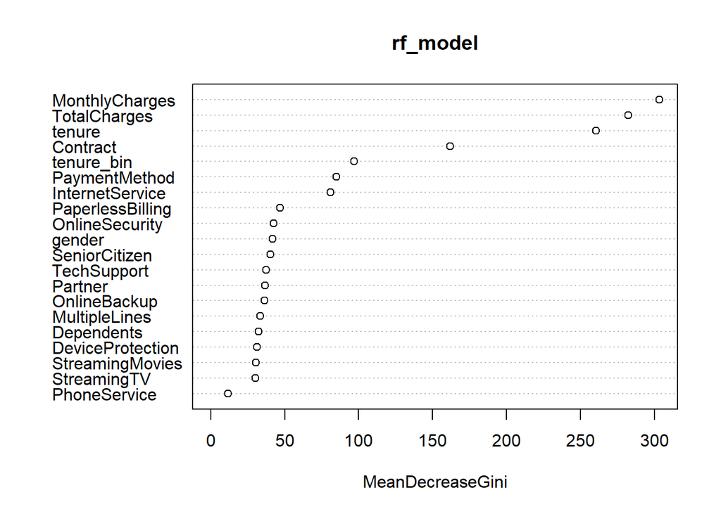

```r
varImpPlot(rf_model)
```